# Module 3: Mixed effects models

Aya Mitani

# Linear mixed effects models

## Linear mixed effects models

- So far, we have discussed models for longitudinal data where changes in the mean response can be expressed as,

$$E(Y_{i}|X_{i}) = X_{i}\beta,$$
and where the primary goal is to make inferences about the population regression parameters, $\beta$

- Specification of this regression model was completed by making additional assumptions about the structure of $\text{Cov}(Y_{i})=\Sigma_{i}$
- We now consider an alternative, but closely related, approach for analyzing longitudinal data using **linear mixed effects models**

## Basic concept

- Some subset of the regression parameters **vary randomly** from one individual (cluster) to another, thereby accounting for sources of **natural heterogeneity** in the population
- Individuals in the population are assumed to have their own **subject-specific** mean response trajectories over time
- The mean response is modeled as a combination of population characteristics, $\beta$, that are assumed to be **shared** by all individuals, and subject-specific effects, $b_i$, that are **unique** to a particular individual

## Linear mixed effects model

Using vector and matrix notation, the **linear mixed effects model** is expressed as

$$Y_{i} = X_{i}\beta + Z_{i}b_{i} + \epsilon_{i}$$
The three components of the mixed effects models are:

**Fixed effects**

- Variables that are constant across individuals
- $X_{i}$ is a $(n_{i} \times p)$ matrix of **covariates**
- $\beta$ is a $(p \times 1)$ vector of **fixed** effects

**Errors**

- $\epsilon_{i}$ is a $(n_{i} \times 1)$ vector of **errors**

## Linear mixed effects model

Additionally,

- The random effects, $b_{i}$, are assumed to be **independent** of the covariates, $X_{i}$, and has a multivariate normal distribution with mean 0 and covariance matrix $G$
  - $E(b_{i})=0$ and $\text{Cov}(b_{i})=G$
- The errors, $\epsilon_{i}$, are assumed to be **independent** of $b_{i}$, and has a multivariate normal distribution with mean 0 and covariance matrix $R_{i}$
  - $E(\epsilon_{i})=0$ and $\text{Cov}(\epsilon_{i})=R_{i}$
  - Further, we usually assume that $R_{i}$ is the diagonal matrix $\sigma^{2}I_{n_{i}}$
  - It is possible to assume $R_{i}$ to have a non-diagonal covariance structure, but only for **random intercepts models**

## Linear mixed effects model

- With the inclusion of some random effects, the covariances among repeated measures can be expressed as **functions of time**
- Covariance pattern models do not distinguish the different sources of variability that have an impact on the covariance
- Linear mixed effects models
  - explicitly distinguish **between-subject** and **within-subject** sources of variability
  - can also be used to obtain **predictions** of individual growth trajectories over time
  - are well suited for analyzing inherently **unbalanced** longitudinal data

## Mean functions of LMM

The **conditional** or **subject-specific** mean of $Y_{i}$ is given by

$$E(Y_{i}|b_{i}) = X_{i}\beta + Z_{i}b_{i},$$
while the **marginal** or **population-averaged** mean of $Y_{i}$ is given by

$$\begin{align}
E(Y_{i})
&= \mu_{i} \\
&= E\left\{E(Y_{i}|b_{i})\right\} \\
&= E(X_{i}\beta + Z_{i}b_{i}) \\
&= X_{i}\beta + Z_{i}E(b_{i}) \\
&= X_{i}\beta.
\end{align}$$

## Covariance of LMM

In a similar way, we can distinguish between conditional and marginal covariances.

The **conditional covariance** of $Y_{i}$, given $b_{i}$, is

$$\text{Cov}(Y_{i}|b_{i}) = \text{Cov}(\epsilon_{i}) = R_{i},$$

while the **marginal covariance** of $Y_{i}$, averaged over the distribution of $b_{i}$ is

$$\begin{align}
\text{Cov}(Y_{i})
&= \text{Cov}(X_{i}\beta + Z_{i}b_{i} + \epsilon_{i}) \\
&= \text{Cov}(Z_{i}b_{i} + \epsilon_{i}) \\
&= \text{Cov}(Z_{i}b_{i}) + \text{Cov}(\epsilon_{i}) \\
&= Z_{i}\text{Cov}(b_{i})Z^{T}_{i} + \text{Cov}(\epsilon_{i}) \\
&= Z_{i}GZ^{T}_{i} + R_{i} \\
&= Z_{i}GZ^{T}_{i} + \sigma^{2}I_{n_{i}}.
\end{align}$$

Note that this is **not** a diagonal matrix. $\text{Cov}(Y_{i})$ will have non-zero off-diagonal elements, thereby accounting for the **correlation among the repeated measurements** on the same individuals in a longitudinal study.

## Example: random intercepts model

We will revisit the dental study.

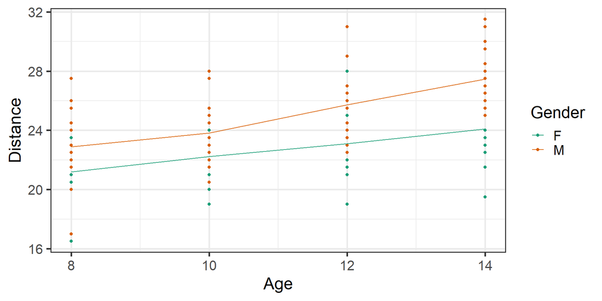

## Example: random intercepts model

- The simplest LMM is one in which a single random intercepts is introduced
- $Z_{i}$ is now a $(n_{i} \times 1)$ vector of 1’s
- $b_{i}$ is a subject-specific deviation around the population intercept, $\beta_0$, with $E(b_{i}) = 0$ and $\text{Var}(b_{i}) = \sigma^{2}_{b}$
- The measurement error is assumed to be random with $E(\epsilon_{ij}) = 0$ and $\text{Var}(\epsilon_{ij}) = \sigma^{2}$
- We will fit the following LMM with random intercepts across subjects
  $$Y_{ij} = \beta_{0} + \beta_{1}\text{Age}^{*}_{ij} + \beta_{2}\text{Gender}_{i} + \beta_{3}\text{Age}^{*}_{ij} \times \text{Gender}_{i} + b_i + \epsilon_{ij}$$
  where $\text{Age}^{*} = \text{Age} - 8 \in (0,2,4,6)$.

## Example: LMM in R

There are two popular packages in R to fit LMM:

- `nlme` and `lmer`

```r
# random intercepts model with nlme package
library(nlme)
fit1 <- lme(distance ~ agestar * gender, random = ~ 1 | id,
            data = dentallong)

# same random intercepts model can be fit with lmer function in lme4 package
library(lme4)
fit1lmer <- lmer(distance ~ agestar * gender + (1|id),
                 data = dentallong)
```

## Example: LMM in R

```r
summary(fit1)
```

```
Linear mixed-effects model fit by REML
  Data: dentallong
       AIC      BIC    logLik
  445.7572 461.6236 -216.8786

Random effects:
 Formula: ~1 | id
        (Intercept) Residual
StdDev:    1.816214 1.386382

Fixed effects:  distance ~ agestar * gender
                    Value Std.Error DF  t-value p-value
(Intercept)     21.209091 0.6497603 79 32.64141  0.0000
agestar          0.479545 0.0934698 79  5.13048  0.0000
genderM          1.406534 0.8440633 25  1.66638  0.1081
agestar:genderM  0.304830 0.1214209 79  2.51052  0.0141
 Correlation:
                (Intr) agestr gendrM
agestar         -0.432
genderM         -0.770  0.332
agestar:genderM  0.332 -0.770 -0.432

Standardized Within-Group Residuals:
        Min          Q1         Med          Q3         Max
-3.59804400 -0.45461690  0.01578365  0.50244658  3.68620792

Number of Observations: 108
Number of Groups: 27
```

- `lme()` (and `lmer()`) uses REML (Restricted Maximum Likelihood estimation) by default to fit LMM
- Likelihood based statistics can be used: AIC, BIC, likelihood ratio test

## Example: LMM in R

```r
summary(fit1)
```

```
Linear mixed-effects model fit by REML
  Data: dentallong
       AIC      BIC    logLik
  445.7572 461.6236 -216.8786

Random effects:
 Formula: ~1 | id
        (Intercept) Residual
StdDev:    1.816214 1.386382

Fixed effects:  distance ~ agestar * gender
                    Value Std.Error DF  t-value p-value
(Intercept)     21.209091 0.6497603 79 32.64141  0.0000
agestar          0.479545 0.0934698 79  5.13048  0.0000
genderM          1.406534 0.8440633 25  1.66638  0.1081
agestar:genderM  0.304830 0.1214209 79  2.51052  0.0141
 Correlation:
                (Intr) agestr gendrM
agestar         -0.432
genderM         -0.770  0.332
agestar:genderM  0.332 -0.770 -0.432

Standardized Within-Group Residuals:
        Min          Q1         Med          Q3         Max
-3.59804400 -0.45461690  0.01578365  0.50244658  3.68620792

Number of Observations: 108
Number of Groups: 27
```

- Marginal mean for Females: $E(Y_{ij}|X_{ij}) = 21.2 + 0.48\text{Age}^{*}_{ij}$
- Marginal mean for Males: $E(Y_{ij}|X_{ij}) = 22.6 + 0.78\text{Age}^{*}_{ij}$

## Example: Marginal covariance structure

- Note that
  - $\hat{\sigma}_b = 1.82$ and $\hat{\sigma}_{\epsilon} = 1.39$
- The marginal variance of each response is given by
  $$\begin{align}
  \text{Var}(Y_{ij})
  &= \text{Var}(X^{T}_{ij}\beta + b_{i} + \epsilon_{ij}) \\
  &= \text{Var}(b_{i} + \epsilon_{ij}) \\
  &= \text{Var}(b_{i}) + \text{Var}(\epsilon_{ij}) \\
  &= \sigma^{2}_{b} + \sigma^{2}_{\epsilon} = 5.22
  \end{align}$$
- The marginal covariance between any pair of responses, $Y_{ij}$ and $Y_{ik}$, is given by
  $$\begin{align}
  \text{Cov}(Y_{ij},Y_{ik})
  &= \text{Cov}(X^{T}_{ij}\beta + b_{i} + \epsilon_{ij}, X^{T}_{ik}\beta + b_{i} + \epsilon_{ik}) \\
  &= \text{Cov}(b_{i} + \epsilon_{ij}, b_{i} + \epsilon_{ik}) \\
  &= \text{Cov}(b_{i}, b_{i}) + \underbrace{\text{Cov}(b_{i}, \epsilon_{ik})}_{0} + \underbrace{\text{Cov}(\epsilon_{ij}, \epsilon_{ik})}_{0} + \underbrace{\text{Cov}(\epsilon_{ij}, b_{i})}_{0} \\
  &= \text{Cov}(b_{i}, b_{i}) \\
  &= \text{Var}(b_{i}) = \sigma^{2}_{b} = 3.30\\
  \end{align}$$

## Example: Marginal covariance structure

The marginal **covariance matrix** of the repeated measurements has the following **compound symmetry** pattern:

$$\text{Cov}(Y_{i}) =
\left(\begin{array}{ccccc}
\sigma^{2}_{b} + \sigma^{2} & \sigma^{2}_{b} & \sigma^{2}_{b} & ...& \sigma^{2}_{b}\\
\sigma^{2}_{b} & \sigma^{2}_{b} + \sigma^{2} & \sigma^{2}_{b} & ... & \sigma^{2}_{b}\\
\sigma^{2}_{b} & \sigma^{2}_{b} & \sigma^{2}_{b} + \sigma^{2} & ... & \sigma^{2}_{b}\\
\vdots & \vdots & \vdots & \ddots & \vdots \\
\sigma^{2}_{b} & \sigma^{2}_{b} & \sigma^{2}_{b} & ... & \sigma^{2}_{b} + \sigma^{2}\\
\end{array}\right).$$
Note: This is the only covariance model that arises in both the patterned and random effects families.

```r
getVarCov(fit1, type = "marginal", individual = 1)
```

```
id 1
Marginal variance covariance matrix
       1      2      3      4
1 5.2207 3.2986 3.2986 3.2986
2 3.2986 5.2207 3.2986 3.2986
3 3.2986 3.2986 5.2207 3.2986
4 3.2986 3.2986 3.2986 5.2207
  Standard Deviations: 2.2849 2.2849 2.2849 2.2849
```

## Example: ICC

The correlation between $Y_{ij}$ and $Y_{ik}$ is
$$\begin{align}
\text{Corr}(Y_{ij}, Y_{ik}) &= \frac{\text{Cov}(Y_{ij}, Y_{ik})}{\sqrt{\text{Var}(Y_{ij})\text{Var}(Y_{ik})}}\\
&= \frac{\sigma_{b}^{2}}{\sqrt{(\sigma_{b}^{2} + \sigma_{\epsilon}^{2})(\sigma_{b}^{2} + \sigma_{\epsilon}^{2})}}\\
&= \frac{\sigma_{b}^{2}}{\sigma_{b}^{2} + \sigma_{\epsilon}^{2}} = 0.63
\end{align}$$
This correlation is referred to as **within-subject** correlation or **intraclass** correlation.

```r
getVarCov(fit1)
```

```
Random effects variance covariance matrix
            (Intercept)
(Intercept)      3.2986
  Standard Deviations: 1.8162
```

```r
fit1$sigma^2
```

```
[1] 1.922055
```

## Simulated visualization of 10 subjects with 5 time points

[figure not shown]

## Prediction

- In many applications where longitudinal data arise, we focus on inference of fixed effects, $\beta$
- However, in some longitudinal studies, we may want to **predict** subject-specific profiles
- Because the linear mixed effects model explicitly distinguishes between fixed and random effects, we can obtain predictions of **subject-specific effects**, $b_{i}$, or of the **subject-specific response trajectories**, $X_{i}\beta + Z_{i}b_{i}$

The best predictor of $b_{i}$ is known as the **best linear unbiased predictor (BLUP)**,
$$E(b_{i}|Y_{i})=GZ^{T}_{i}\Sigma_{i}^{-1}(Y_{i}-X_{i}\hat\beta),$$
where $\Sigma_{i} = \text{Cov}(Y_{i}) = Z_{i}GZ^{T}_{i} + R_{i}$.

When we replace the unknown covariance parameters by their REML estimates, we obtain the **empirical BLUP**,
$$\hat{b}_{i}=\hat{G}Z_{i}^{T}\hat\Sigma_{i}^{-1}(Y_{i}-X_{i}\hat\beta).$$
Given the empirical BLUP, $\hat{b}_{i}$, we can also obtain the $i$th subject’s predicted response profile as:
$$\hat{Y}_{i}=X_{i}\hat\beta+Z_{i}\hat{b}_{i}.$$

## Prediction

Coefs of fixed effects

```r
coef(summary(fit1))
```

```
                     Value  Std.Error DF   t-value      p-value
(Intercept)     21.2090909 0.64976026 79 32.641410 1.283538e-47
agestar          0.4795455 0.09346985 79  5.130483 2.017414e-06
genderM          1.4065341 0.84406334 25  1.666385 1.081190e-01
agestar:genderM  0.3048295 0.12142090 79  2.510520 1.409745e-02
```

($\hat{\beta}_0 + \hat{b}_i$), and coefs of fixed effects

```r
coef(fit1)[1:15,]
```

```
   (Intercept)   agestar  genderM agestar:genderM
1     20.09819 0.4795455 1.406534       0.3048295
2     21.51657 0.4795455 1.406534       0.3048295
3     22.17121 0.4795455 1.406534       0.3048295
4     23.15317 0.4795455 1.406534       0.3048295
5     21.18925 0.4795455 1.406534       0.3048295
6     19.87998 0.4795455 1.406534       0.3048295
7     21.51657 0.4795455 1.406534       0.3048295
8     21.84389 0.4795455 1.406534       0.3048295
9     19.87998 0.4795455 1.406534       0.3048295
10    17.58874 0.4795455 1.406534       0.3048295
11    24.46245 0.4795455 1.406534       0.3048295
12    23.63671 0.4795455 1.406534       0.3048295
13    19.81798 0.4795455 1.406534       0.3048295
14    20.58173 0.4795455 1.406534       0.3048295
15    22.65475 0.4795455 1.406534       0.3048295
```

Empirical BLUP

```r
ranef(fit1)[1:20,]
```

```
 [1] -1.11090166  0.30748171  0.96212019  1.94407791 -0.01983753 -1.32911449
 [7]  0.30748171  0.63480095 -1.32911449 -3.62034916  3.25335486  2.42761769
[13] -1.39110677 -0.62736188  1.44565997 -1.71842601  1.22744715 -1.06378753
[19] -0.95468112  0.13638302
```

## Prediction

Here is a plot of the estimated **marginal** and **conditional** means by gender.

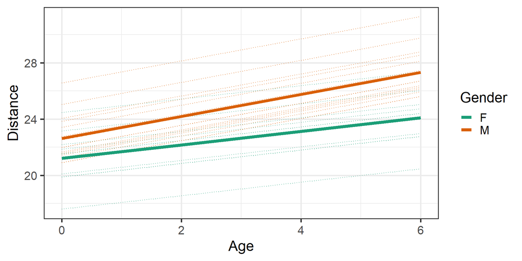

## Example: random intercepts and slopes model

- We can allow additional regression coefficients to vary randomly
- A very **flexible**, yet **parsimonious**, class of random effects covariance structures become available by allowing a subset of regression coefficients (other than just the intercept) to vary randomly

$$Y_{ij} = \beta_{0} + \beta_{1}\text{Age}^{*}_{ij} + \beta_{2}\text{Gender}_{i} + \beta_{3}\text{Age}^{*}_{ij} \times \text{Gender}_{i} + b_{i0} + b_{i1}\text{Age}^{*}_{ij} + \epsilon_{ij}$$

The vector of random effects for individual $i$, $b_{i}$, is $2 \times 1$:
$$b_{i} =
\left(\begin{array}{cc}
b_{0i} \\
b_{1i}
\end{array}\right) \quad \text{with} \quad
E(b_{i}) =
\left(\begin{array}{cc}
0 \\
0
\end{array}\right) \\\$$

$$\text{and} \quad \begin{align}
G = \text{Cov}(b_{i}) =
\left(\begin{array}{cc}
\text{Var}(b_{0i}) & \text{Cov}(b_{1i},b_{1i}) \\
\text{Cov}(b_{0i},b_{1i}) & \text{Var}(b_{1i})
\end{array}\right)
=\left(\begin{array}{cc}
g_{00} & g_{10} \\
g_{10} & g_{11}
\end{array}\right) \\
\end{align}$$

## Example: Covariance

So, remember that $\text{Cov}(Y_{i}) = Z_{i}GZ^{T}_{i} + \sigma^{2}I_{n_{i}}$?

We can further show that

$$\text{Var}(Y_{ij}) = g_{11} + 2t_{ij}g_{12} + t_{ij}^{2}g_{22} + \sigma^{2}$$
and

$$\text{Cov}(Y_{ij},Y_{ik}) = g_{11} + (t_{ij}+t_{ik})g_{12} + t_{ij}t_{ik}g_{22}.$$
Therefore, $\text{Cov}(Y_{i})$ can be expressed as a **function of time**, $t_{ij}$!

Thus, we can construct a very **flexible** covariance structure in a more **parsimonious** way with a linear mixed effects model than with a covariance pattern model.

## Example: LMM in R

```r
## random intercepts + random slopes

fit2 <- lme(distance ~ agestar * gender, random = ~ agestar | id,
            data = dentallong)
summary(fit2)
```

```
Linear mixed-effects model fit by REML
  Data: dentallong
       AIC      BIC    logLik
  448.5817 469.7368 -216.2908

Random effects:
 Formula: ~agestar | id
 Structure: General positive-definite, Log-Cholesky parametrization
            StdDev    Corr
(Intercept) 1.7983213 (Intr)
agestar     0.1803446 -0.091
Residual    1.3100400

Fixed effects:  distance ~ agestar * gender
                    Value Std.Error DF  t-value p-value
(Intercept)     21.209091 0.6349877 79 33.40079  0.0000
agestar          0.479545 0.1037192 79  4.62350  0.0000
genderM          1.406534 0.8248732 25  1.70515  0.1006
agestar:genderM  0.304830 0.1347352 79  2.26243  0.0264
 Correlation:
                (Intr) agestr gendrM
agestar         -0.396
genderM         -0.770  0.305
agestar:genderM  0.305 -0.770 -0.396

Standardized Within-Group Residuals:
         Min           Q1          Med           Q3          Max
-3.168084278 -0.385940425  0.007102881  0.445155637  3.849462350

Number of Observations: 108
Number of Groups: 27
```

## Example: LMM in R

```r
getVarCov(fit2)
```

```
Random effects variance covariance matrix
            (Intercept)   agestar
(Intercept)     3.23400 -0.029430
agestar        -0.02943  0.032524
  Standard Deviations: 1.7983 0.18034
```

```r
getVarCov(fit2, type = "conditional", individual = 1)
```

```
id 1
Conditional variance covariance matrix
       1      2      3      4
1 1.7162 0.0000 0.0000 0.0000
2 0.0000 1.7162 0.0000 0.0000
3 0.0000 0.0000 1.7162 0.0000
4 0.0000 0.0000 0.0000 1.7162
  Standard Deviations: 1.31 1.31 1.31 1.31
```

```r
getVarCov(fit2, type = "marginal", individual = 1)
```

```
id 1
Marginal variance covariance matrix
       1      2      3      4
1 4.9502 3.1751 3.1162 3.0574
2 3.1751 4.9625 3.3176 3.3888
3 3.1162 3.3176 5.2351 3.7202
4 3.0574 3.3888 3.7202 5.7679
  Standard Deviations: 2.2249 2.2277 2.288 2.4016
```

## Prediction

Coefs of fixed effects

```r
coef(summary(fit2))
```

```
                     Value Std.Error DF   t-value      p-value
(Intercept)     21.2090909 0.6349877 79 33.400791 2.355197e-48
agestar          0.4795455 0.1037192 79  4.623497 1.450038e-05
genderM          1.4065341 0.8248732 25  1.705152 1.005635e-01
agestar:genderM  0.3048295 0.1347352 79  2.262434 2.641737e-02
```

($\hat{\beta} + \hat{b}_i$), and coefs of fixed effects

```r
coef(fit2)[1:15,]
```

```
   (Intercept)   agestar  genderM agestar:genderM
1     20.20973 0.4347906 1.406534       0.3048295
2     21.27124 0.5698385 1.406534       0.3048295
3     21.86869 0.5931100 1.406534       0.3048295
4     23.09591 0.5077588 1.406534       0.3048295
5     21.34035 0.4245822 1.406534       0.3048295
6     19.99832 0.4314874 1.406534       0.3048295
7     21.45516 0.5030282 1.406534       0.3048295
8     22.04814 0.4077676 1.406534       0.3048295
9     20.07189 0.4047633 1.406534       0.3048295
10    17.72334 0.4168475 1.406534       0.3048295
11    24.21723 0.5810259 1.406534       0.3048295
12    23.43918 0.5605548 1.406534       0.3048295
13    19.86825 0.4559825 1.406534       0.3048295
14    20.62658 0.4608625 1.406534       0.3048295
15    23.05798 0.3385788 1.406534       0.3048295
```

Empirical BLUP

```r
ranef(fit2)[1:15,]
```

```
   (Intercept)     agestar
1  -0.99935906 -0.04475486
2   0.06215019  0.09029305
3   0.65959712  0.11356455
4   1.88681466  0.02821331
5   0.13125688 -0.05496323
6  -1.21076904 -0.04805801
7   0.24606527  0.02348278
8   0.83905286 -0.07177790
9  -1.13720301 -0.07478212
10 -3.48574837 -0.06269797
11  3.00814249  0.10148040
12  2.23009231  0.08100932
13 -1.34084182 -0.02356295
14 -0.58251537 -0.01868296
15  1.84888413 -0.14096669
```

## Prediction

Here is a plot of the estimated **marginal** and **conditional** means by gender.

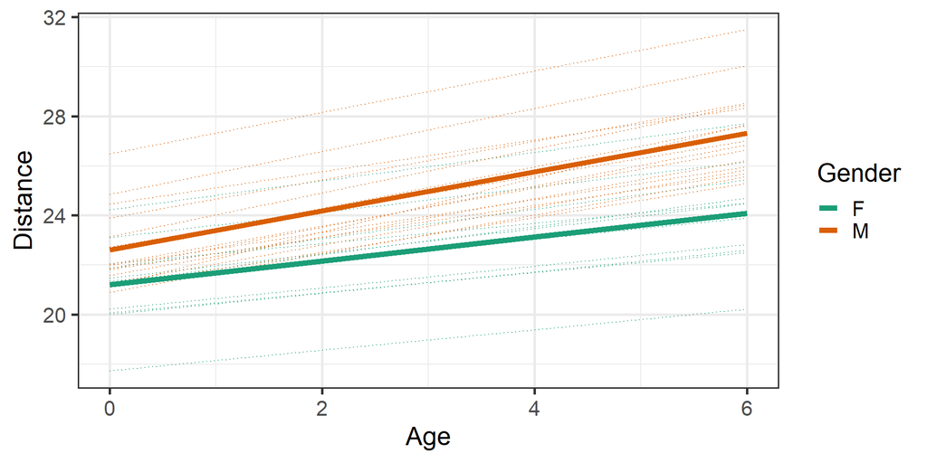

## Random intercepts and covariance pattern model

- We can introduce more flexibility by explicitly by modeling the correlation structure in $R_{i}$, i.e. move beyond $ R_{i} = ^{2}I_{n_{i}}$ and permit the $\epsilon_{i}$ to be correlated
- The hybrid random intercepts and covariance pattern model looks like:
  $$Y_{ij} = X^{T}_{ij}\beta + b_{0i} + U_{i}(t_{ij}) + \epsilon^{*}_{ij},$$
  where
  - $b_{0i}$ is an individual-specific random intercept with $E(b_{0i})=0$ and $\text{Var}(b_{0i}) = \sigma^{2}_{b}$
  - $U_{i}(t_{ij})$ is a covariance pattern (serial dependence) term
  - We assume $E(\epsilon^{*}_{ij})=0$ and $\text{Var}(\epsilon^{*}_{ij}) = \sigma^{2}$
  - Finally, we assume $U_{i}(t_{ij})$ are assumed to have a normal distribution, with zero mean, variance $\sigma^{2}_{u}$, and correlation: $\text{Corr}\left\{U_{i}(t_{ij}),U_{i}(t_{ik})\right\} = \rho(|t_{ij}-t_{ik}|)$
- $\epsilon^{*}_{ij}$ captures the variation in error terms beyond that is explained by $U_{i}(t_{ij})$

## Example: random intercepts + AR1 errors

```r
fit3 <- lme(distance ~ agestar * gender, random = ~ 1 | id,
            corr = corCAR1(form = ~ agestar | id), data = dentallong)
getVarCov(fit3, type = "conditional", individual = 1)
```

```
id 1
Conditional variance covariance matrix
           1          2          3          4
1 1.9221e+00 5.0927e-08 1.3494e-15 3.5753e-23
2 5.0927e-08 1.9221e+00 5.0927e-08 1.3494e-15
3 1.3494e-15 5.0927e-08 1.9221e+00 5.0927e-08
4 3.5753e-23 1.3494e-15 5.0927e-08 1.9221e+00
  Standard Deviations: 1.3864 1.3864 1.3864 1.3864
```

```r
getVarCov(fit3, type = "marginal", individual = 1)
```

```
id 1
Marginal variance covariance matrix
       1      2      3      4
1 5.2207 3.2986 3.2986 3.2986
2 3.2986 5.2207 3.2986 3.2986
3 3.2986 3.2986 5.2207 3.2986
4 3.2986 3.2986 3.2986 5.2207
  Standard Deviations: 2.2849 2.2849 2.2849 2.2849
```

## Example: random intercepts + exponential errors

```r
fit4 <- lme(distance ~ agestar * gender, random = ~ 1 | id,
            corr = corExp(form = ~ agestar | id), data = dentallong)
getVarCov(fit4, type = "conditional", individual = 1)
```

```
id 1
Conditional variance covariance matrix
           1          2          3          4
1 1.9221e+00 3.5416e-08 6.5257e-16 1.2024e-23
2 3.5416e-08 1.9221e+00 3.5416e-08 6.5257e-16
3 6.5257e-16 3.5416e-08 1.9221e+00 3.5416e-08
4 1.2024e-23 6.5257e-16 3.5416e-08 1.9221e+00
  Standard Deviations: 1.3864 1.3864 1.3864 1.3864
```

```r
getVarCov(fit4, type = "marginal", individual = 1)
```

```
id 1
Marginal variance covariance matrix
       1      2      3      4
1 5.2207 3.2986 3.2986 3.2986
2 3.2986 5.2207 3.2986 3.2986
3 3.2986 3.2986 5.2207 3.2986
4 3.2986 3.2986 3.2986 5.2207
  Standard Deviations: 2.2849 2.2849 2.2849 2.2849
```

## Example: random intercepts + heteroskedasticity errors across age

```r
fit5 <- lme(distance ~ agestar * gender, random = ~ 1 | id,
            weights = varIdent(form = ~ 1 | agestar), data = dentallong)
getVarCov(fit5, type = "conditional", individual = 1)
```

```
id 1
Conditional variance covariance matrix
       1      2      3      4
1 2.7331 0.0000 0.0000 0.0000
2 0.0000 1.4798 0.0000 0.0000
3 0.0000 0.0000 2.2128 0.0000
4 0.0000 0.0000 0.0000 1.3182
  Standard Deviations: 1.6532 1.2165 1.4875 1.1481
```

```r
getVarCov(fit5, type = "marginal", individual = 1)
```

```
id 1
Marginal variance covariance matrix
       1      2      3      4
1 6.0322 3.2991 3.2991 3.2991
2 3.2991 4.7789 3.2991 3.2991
3 3.2991 3.2991 5.5119 3.2991
4 3.2991 3.2991 3.2991 4.6172
  Standard Deviations: 2.4561 2.1861 2.3477 2.1488
```

## Example: random intercepts + heteroskedasticity errors across gender

```r
fit6 <- lme(distance ~ agestar * gender, random = ~ 1 | id,
            weights = varIdent(form = ~ 1 | gender), data = dentallong)
getVarCov(fit6, type = "conditional", individual = 1) # female
```

```
id 1
Conditional variance covariance matrix
        1       2       3       4
1 0.61043 0.00000 0.00000 0.00000
2 0.00000 0.61043 0.00000 0.00000
3 0.00000 0.00000 0.61043 0.00000
4 0.00000 0.00000 0.00000 0.61043
  Standard Deviations: 0.7813 0.7813 0.7813 0.7813
```

```r
getVarCov(fit6, type = "conditional", individual = 27) # male
```

```
id 27
Conditional variance covariance matrix
       1      2      3      4
1 2.7883 0.0000 0.0000 0.0000
2 0.0000 2.7883 0.0000 0.0000
3 0.0000 0.0000 2.7883 0.0000
4 0.0000 0.0000 0.0000 2.7883
  Standard Deviations: 1.6698 1.6698 1.6698 1.6698
```

## Example: random intercepts + heteroskedasticity errors across gender

```r
getVarCov(fit6, type = "marginal", individual = 1) # female
```

```
id 1
Marginal variance covariance matrix
       1      2      3      4
1 4.0239 3.4135 3.4135 3.4135
2 3.4135 4.0239 3.4135 3.4135
3 3.4135 3.4135 4.0239 3.4135
4 3.4135 3.4135 3.4135 4.0239
  Standard Deviations: 2.006 2.006 2.006 2.006
```

```r
getVarCov(fit6, type = "marginal", individual = 27) # male
```

```
id 27
Marginal variance covariance matrix
       1      2      3      4
1 6.2018 3.4135 3.4135 3.4135
2 3.4135 6.2018 3.4135 3.4135
3 3.4135 3.4135 6.2018 3.4135
4 3.4135 3.4135 3.4135 6.2018
  Standard Deviations: 2.4903 2.4903 2.4903 2.4903
```

## Comparing AIC and BIC

```r
AIC(fit) # gives you AIC
BIC(fit) # gives you BIC
```

| Covariance model | AIC | BIC |
| --- | --- | --- |
| 1. Random intercepts + ind errors | 445.76 | 461.62 |
| 2. Random intercepts and slopes + ind errors | 448.58 | 469.74 |
| 3. Random intercepts + AR1 errors | 447.76 | 466.27 |
| 4. Random intercepts + exp errors | 447.76 | 466.27 |
| 5. Random intercepts + heteroske ind errors (age) | 449.80 | 473.60 |
| 6. Random intercepts + heteroske ind errors (gender) | 429.22 | 447.73 |

- Model 6 (Random intercepts + heterogeneous variance terms across gender) has the lowest AIC and BIC

## Comparing coefficient estimates and standard errors for $\beta_{3}$

| Covariance model | Estimate | StdError |
| --- | --- | --- |
| 1. Random intercepts + ind errors | 0.305 | 0.121 |
| 2. Random intercepts and slopes + ind errors | 0.305 | 0.135 |
| 3. Random intercepts + AR1 errors | 0.305 | 0.121 |
| 4. Random intercepts + exp errors | 0.305 | 0.121 |
| 5. Random intercepts + heteroske ind errors (age) | 0.336 | 0.119 |
| 6. Random intercepts + heteroske ind errors (gender) | 0.305 | 0.107 |

- $\hat\beta_{3}$ are very similar across all models
- Model 6 has the smallest standard errors

# Generalized linear mixed effects models

## Generalized linear mixed effects models

- GLMs can be extended to longitudinal (clustered) data by allowing a subset of the regression coefficients to **vary randomly** from one individual (cluster) to another
- The concept of GLMMs are similar to LMM
  - However, introduction of random effects in GLMs is more complicated

GLMM formulation

$$g\left\{E(Y_{ij}|b_{i})\right\} = X_{ij}^{T}\beta + Z_{ij}^{T}b_{i}$$

for some **known** link function $g(\cdot)$.

## Interpretation of regression parameters

- The introduction of random effects has important implications for the interpretation of the regression coefficients, $\beta$, in GLMM
- In GLMM, $\beta$ has **subject-specific** interpretations
- $\beta$ represents the **within-subject** changes in covariates on changes in an individual’s **transformed** mean response, while holding the remaining covariates constant

For example, consider a simple logistic regression model with randomly varying intercepts:
$$\text{log}\left\{\frac{\Pr(Y_{ij}=1|b_{i})}{\Pr(Y_{ij}=0|b_{i})}\right\} = \beta_{1} + \beta_{2}X_{ij} + b_{i},$$
where $b_{i} \sim N(0, g_{11})$.

## Interpretation of regression parameters

When $X_{ij} = x$, then the log odds of a positive response $Y_{ij}=1$ is
$$\text{log}\left\{\frac{\Pr(Y_{ij}=1|b_{i}, X_{ij}=x)}{\Pr(Y_{ij}=0|b_{i}, X_{ij}=x)}\right\} = \beta_{1} + \beta_{2}x + b_{i}.$$
Similarly, when $X_{ij}=x+1$, then the log odds of $Y_{ij}=1$ is
$$\text{log}\left\{\frac{\Pr(Y_{ij}=1|b_{i}, X_{ij}=x+1)}{\Pr(Y_{ij}=0|b_{i}, X_{ij}=x+1)}\right\} = \beta_{1} + \beta_{2}(x+1) + b_{i}.$$
For any individual $i$, the **difference in log odds** of a positive response for a unit increase in $X_{ij}$ is
$$\begin{aligned}
\text{log}\left\{\frac{\Pr(Y_{ij}=1|b_{i}, X_{ij}=x+1)}{\Pr(Y_{ij}=0|b_{i}, X_{ij}=x+1)}\right\} &- \text{log}\left\{\frac{\Pr(Y_{ij}=1|b_{i}, X_{ij}=x)}{\Pr(Y_{ij}=0|b_{i}, X_{ij}=x)}\right\} \\
&= \beta_{1} + \beta_{2}(x+1) + b_{i} - \left\{\beta_{1} + \beta_{2}x + b_{i}\right\} \\
&= \beta_{2}.
\end{aligned}$$

## Interpretation of regression parameters

Furthermore,
$$\begin{aligned}
\text{log}\left\{\frac{\Pr(Y_{ij}=1|b_{i}, X_{ij}=x+1)}{\Pr(Y_{ij}=0|b_{i}, X_{ij}=x+1)} \bigg/ \frac{\Pr(Y_{ij}=1|b_{i}, X_{ij}=x)}{\Pr(Y_{ij}=0|b_{i}, X_{ij}=x)}\right\}
&= \beta_{2} \\
\left\{\frac{\Pr(Y_{ij}=1|b_{i}, X_{ij}=x+1)}{\Pr(Y_{ij}=0|b_{i}, X_{ij}=x+1)} \bigg/ \frac{\Pr(Y_{ij}=1|b_{i}, X_{ij}=x)}{\Pr(Y_{ij}=0|b_{i}, X_{ij}=x)}\right\}
&= e^{\beta_{2}}.
\end{aligned}$$
Therefore, $e^{\beta_{2}}$ is the odds ratio of a positive response for a unit increase in $X_{ij}$ for any given **individual** having some unobservable underlying propensity to respond positively, $b_{i}$.

## Subject-specific covariatess

- Because the components of the fixed effects, $\beta$, have interpretations that depend on holding $b_{i}$ fixed, they are often referred to as **subject-specific** regression coefficients
- The subject-specific interpretations of $\beta$ is more natural for covariates that **vary within an individual** (within-subject or time-varying covariates).
  - For example, age, BMI, smoking status, etc.
  - But covariates are assumed to be independent of the random effects (**assumption of endogeneity**) $\rightarrow$ more on this next week
  - Interpretation of $\beta$ is the change in an **individual’s log odds of response** for a unit increase in $X_{ij}$

## Between-subject covariatess

- What if $X_{ij}$ is a between-subject covariate, such as gender, treatment, or exposure group?
- Then, the change in the value of the covariate requires also a change in index $i$ of $X_{ij}$ to $X_{i'j}$ for $i \neq i'$
  - However, $\beta$ then becomes confounded with $b_{i} - b_{i'}$
  - So we need to assume $b_{i} = b_{i'}$
  - The interpretation of $\beta$ is the change in log odds of response for two different individuals who **happen to have the same value** for the random effect, but who differ by one unit in the covariate $X_{ij}$

## Special case of the identity link functions

- GLMM with the identity link function is equivalent to LMM
- With the identity link function, the regression coefficients in the model for the conditional means,
  $$E(Y_{ij}|X_{ij}, b_{i}) = X_{ij}^{T}\beta + Z_{ij}^{T}b_{i},$$
  also happen to have interpretation in terms of the population means, since
  $$\begin{aligned}
  E(Y_{ij}|X_{ij}) &= E\left\{E(Y_{ij}|X_{ij}, b_{i})\right\} \\
  &= E(X_{ij}^{T}\beta + Z_{ij}^{T}b_{i}) \\
  &= X_{ij}^{T}\beta + Z_{ij}^{T}E(b_{i}) \\
  &= X_{ij}^{T}\beta
  \end{aligned}$$
  when averaged over all individuals in the study population.

## GLMM with non-identity link functions

However, for the non-identity link function, such as logit($\cdot$) or log($\cdot$), that are usually adopted for discrete responses, this relationship no longer holds. That is, if
$$g\left\{E(Y_{ij}|X_{ij}, b_{i})\right\} = X_{ij}^{T}\beta + Z_{ij}^{T}b_{i}$$
where $g(\cdot)$ is a non-identity link function, then
$$g\left\{E(Y_{ij}|X_{ij})\right\} \neq X_{ij}^{T}\beta.$$

For non-identity link functions, the regression coefficients in GLMM and **marginal models** have quite distinct interpretations, and they have different targets of inference.

## Example: Respiratory study

Percent of good respiratory status over time by clinic

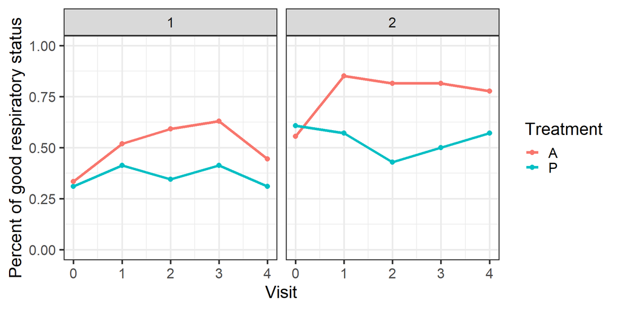

## Example: Random intercepts model

- In R, the `glmer()` function in `lme4` package is most popular for GLMM

```r
glmm1 <- glmer(resp ~ trt1 + visit + clinic2 + (1|id),
                data = respl,
                nAGQ = 50, # number of quadrature points (default is 1)
                family = binomial("logit"))
```

- In maximum likelihood estimation, GLMM has **no closed-form solutions**
- Instead, we use a **numerical integration technique** called **Gaussian quadrature** to approximate the marginal likelihood as a weighted sum with the number of **quadrature points**, $K$
- When $K = 1$, this technique is referred to as **Laplace** approximation
- The higher the $K$, the more accurate the approximation will be
- But the computational burden also increases with increasing $K$
  - `nAGQ > 1` option in `glmer()` is only available for random intercepts model

## Example: Random intercepts model

```r
summary(glmm1)
```

```
Generalized linear mixed model fit by maximum likelihood (Adaptive
  Gauss-Hermite Quadrature, nAGQ = 50) [glmerMod]
 Family: binomial  ( logit )
Formula: resp ~ trt1 + visit + clinic2 + (1 | id)
   Data: respl

     AIC      BIC   logLik deviance df.resid
   607.1    628.7   -298.5    597.1      550

Scaled residuals:
    Min      1Q  Median      3Q     Max
-2.3262 -0.3826  0.2129  0.4866  1.9096

Random effects:
 Groups Name        Variance Std.Dev.
 id     (Intercept) 5.039    2.245
Number of obs: 555, groups:  id, 111

Fixed effects:
            Estimate Std. Error z value Pr(>|z|)
(Intercept) -1.46035    0.48214  -3.029  0.00245 **
trt1         1.41586    0.51743   2.736  0.00621 **
visit        0.11067    0.08359   1.324  0.18552
clinic2      1.57903    0.51698   3.054  0.00226 **
---
Signif. codes:  0 '***' 0.001 '**' 0.01 '*' 0.05 '.' 0.1 ' ' 1

Correlation of Fixed Effects:
        (Intr) trt1   visit
trt1    -0.564
visit   -0.368  0.023
clinic2 -0.577  0.076  0.025
```

## Intra-cluster correlation

For binary GLMM, we can assume that $Y_{ij}$ is generated by an **unobserved latent continuous variable**, $L_{ij}$, such that
$$L_{ij} = X_{ij}\beta + b_{j} + \epsilon_{ij}$$
where $b_{j}\sim N(0,\sigma^{2}_{b})$, and $\epsilon_{ij}\sim Logistic(0,1)$ with $\text{var}(\epsilon_{ij})=\pi^{2}/3$.

- Without loss of generosity, we can assume that
  $$Y_{ij}=
  \begin{cases}
  1 \text{ if } L_{ij}>0 \\
  0 \text{ if } L_{ij}\leq 0
  \end{cases} \quad$$
- We can then quantify the relative magnitudes of the between-cluster and within-cluster sources of variability using the intra-cluster correlation
  $$\rho = \text{Corr}(L_{ij}, L_{i'j}) = \frac{\sigma^{2}_{b}}{\sigma^{2}_{b}+\pi^{2}/3} = \frac{5.039}{5.039+\pi^{2}/3} = 0.605$$
- Note that $\rho$ is the marginal correlation among the latent variables $L_{ij}$ and $L_{i'j}$ and **not** the marginal correlation among the observed variables $Y_{ij}$ and $Y_{i'j}$

## Comparing marginal vs conditional model

- In module 2, we fit a marginal model with working exchangeable assumption
- ORs between marginal and conditional models are quite different

| **Variable** | **Marginal model** **OR**<sup>1</sup> | **Marginal model** **95% CI**<sup>1</sup> | **Marginal model** **p-value** | **Conditional model** **OR**<sup>1</sup> | **Conditional model** **95% CI**<sup>1</sup> | **Conditional model** **p-value** |
| --- | --- | --- | --- | --- | --- | --- |
| trt1 | 2.21 | 1.24, 3.92 | 0.007 | 4.12 | 1.49, 11.4 | 0.006 |
| visit | 1.07 | 0.96, 1.18 | 0.2 | 1.12 | 0.95, 1.32 | 0.2 |
| clinic2 | 2.51 | 1.41, 4.47 | 0.002 | 4.85 | 1.76, 13.4 | 0.002 |

<sup>1</sup> OR = Odds Ratio, CI = Confidence Interval

## Example: Random intercepts and slopes model

- Need to use the default **Laplace** approximation

```r
glmm2 <- glmer(resp ~ trt1 * visit + clinic2 + (1 + visit|id),
                data = respl,
                family = binomial("logit"))
summary(glmm2)
```

```
Generalized linear mixed model fit by maximum likelihood (Laplace
  Approximation) [glmerMod]
 Family: binomial  ( logit )
Formula: resp ~ trt1 * visit + clinic2 + (1 + visit | id)
   Data: respl

     AIC      BIC   logLik deviance df.resid
   611.8    646.3   -297.9    595.8      547

Scaled residuals:
    Min      1Q  Median      3Q     Max
-2.1795 -0.4118  0.1588  0.4847  1.9546

Random effects:
 Groups Name        Variance Std.Dev. Corr
 id     (Intercept) 2.8175   1.6785
        visit       0.1692   0.4114   0.64
Number of obs: 555, groups:  id, 111

Fixed effects:
            Estimate Std. Error z value Pr(>|z|)
(Intercept)  -1.0490     0.4656  -2.253  0.02425 *
trt1          0.5930     0.5288   1.121  0.26217
visit        -0.1017     0.1373  -0.741  0.45895
clinic2       1.5312     0.5199   2.945  0.00323 **
trt1:visit    0.4991     0.2206   2.262  0.02370 *
---
Signif. codes:  0 '***' 0.001 '**' 0.01 '*' 0.05 '.' 0.1 ' ' 1

Correlation of Fixed Effects:
           (Intr) trt1   visit  clinc2
trt1       -0.617
visit      -0.312  0.269
clinic2    -0.629  0.118  0.058
trt1:visit  0.223 -0.362 -0.698 -0.063
```

## Example: Nested random effects

- Instead of including the clinic effect as a fixed effect, we can include it as a random effect
- We will fit the following **three-level** GLMM
  $$\begin{aligned}
  \text{logit}\left\{E(Y_{ijk}|b^{(3)}_{k},b^{(2)}_{ik})\right\}&=\beta_1 + \beta_2 \text{Trt}_i + \beta_3 \text{Visit}_{ij} +b^{(2)}_{ik} + b^{(3)}_{k}
  \end{aligned}$$
  where $Y_{ijk}=1$ if patient $i$ in clinic $k$ at time $j$ has the outcome and $Y_{ijk} =0$ otherwise and $b_{ik}^{(2)} \sim N(0, \sigma_{2}^2)$, $b_{k}^{(3)} \sim N(0,\sigma_{3}^2)$.

```r
glmm3 <- glmer(resp ~ trt1 * visit + (1|id) + (1|clinic2),
                data = respl,
                family = binomial("logit"))
```

## Example: Nested random effects

```r
summary(glmm3)
```

```
Generalized linear mixed model fit by maximum likelihood (Laplace
  Approximation) [glmerMod]
 Family: binomial  ( logit )
Formula: resp ~ trt1 * visit + (1 | id) + (1 | clinic2)
   Data: respl

     AIC      BIC   logLik deviance df.resid
   616.6    642.5   -302.3    604.6      549

Scaled residuals:
    Min      1Q  Median      3Q     Max
-2.7590 -0.4377  0.2077  0.4857  2.0290

Random effects:
 Groups  Name        Variance Std.Dev.
 id      (Intercept) 4.7046   2.1690
 clinic2 (Intercept) 0.4867   0.6976
Number of obs: 555, groups:  id, 111; clinic2, 2

Fixed effects:
            Estimate Std. Error z value Pr(>|z|)
(Intercept) -0.35184    0.64494  -0.546   0.5854
trt1         0.75219    0.59921   1.255   0.2094
visit       -0.05239    0.11454  -0.457   0.6474
trt1:visit   0.34498    0.16908   2.040   0.0413 *
---
Signif. codes:  0 '***' 0.001 '**' 0.01 '*' 0.05 '.' 0.1 ' ' 1

Correlation of Fixed Effects:
           (Intr) trt1   visit
trt1       -0.451
visit      -0.352  0.378
trt1:visit  0.233 -0.528 -0.680
```

## Example: Intra-class correlation

What is the correlation between patient $i$ and patient $i'$ in the same clinic $k$?

Note that
$$\begin{aligned}
\text{Cov}(L_{ijk}, L_{i'jk})
&= \text{Cov}(b_{ik}^{(2)}+b_{k}^{(3)}+\epsilon_{ijk}, b_{ik}^{(2)}+b_{k}^{(3)}+\epsilon_{i'jk}) \\
&= \text{Cov}(b_{ik}^{(2)},b_{ik}^{(2)}) + \text{Cov}(b_{k}^{(3)},b_{k}^{(3)}) \\
&= \text{Var}(b_{ik}^{(2)}) + \text{Var}(b_{k}^{(3)}) \\
&= \sigma_{2}^{2} + \sigma_{3}^{2},
\end{aligned}$$

and
$$\begin{aligned}
\text{Var}(L_{ijk})&=\text{Var}(b_{ik}^{(2)}+b_{k}^{(3)}+\epsilon_{ijk})\\
&=\text{Var}(b_{ik}^{(2)})+\text{Var}(b_{k}^{(3)})+\pi^2/3\\
&= \sigma_{2}^{2} + \sigma_{3}^{2}+\pi^2/3,
\end{aligned}$$

## Example: Intra-class correlation

which means that
$$\begin{aligned}
\text{Corr}(Y_{ijk}, Y_{i'jk})
&= \frac{\hat\sigma_{2}^{2} + \hat\sigma_{3}^{2}}{\sqrt{(\hat\sigma_{2}^{2} + \hat\sigma_{3}^{2}+\pi^2/3)(\hat\sigma_{2}^{2} + \hat\sigma_{3}^{2}+\pi^2/3)}}.
\end{aligned}$$
Therefore,

```r
sum.glmm3 <- summary(glmm3)
sum.glmm3$varcor
```

```
 Groups  Name        Std.Dev.
 id      (Intercept) 2.16900
 clinic2 (Intercept) 0.69763
```

```r
var2 <- as.numeric(sum.glmm3$varcor$id)
var3 <- as.numeric(sum.glmm3$varcor$clinic2)
intracl <- (var2 + var3) / (var2 + var3 + pi^2/3)
intracl
```

```
[1] 0.6120946
```

## Conclusion

- GLMMs, fit via ML, and marginal models for dependent data, fit via GEE, represent the two main regression frameworks for cluster-correlated or longitudinal data

**Mixed effects models**

- are more useful when the main scientific objective is to make inference about **individuals**
- addresses scientific questions that are concerned with changes in the (transformed) mean response over time for any individual
- estimation is based on maximum likelihood

**Marginal models**

- are more useful for **population averages**
- addresses scientific questions that are concerned with changes in the (transformed) mean response over time in the study population
- estimation via GEE (semi-parametric)